# Supervised Learning on the Iris Dataset

Eduardo Vallejo

2026-01-04

```
# 1 - Load the data

# 2 - Split the data into:

  # - training set

  # - validation (or test) set


# 3 - Train the model on the training set

# 4 - Evaluate it on the validation set

# 5 - Tune and improve the model
```

## 1 - Load the data

```
# Load the dataset named iris into my workspace so I can use it.”

## After this, an object called iris appears in your environment.

## creates a variable called dataset = iris object

dataset \<- iris
```

```r
# attach the iris dataset to the environment
data(iris)
# rename the dataset
dataset <- iris
```

# - Split the data into:

```
## - training set

## - validation (or test) set

We will split the loaded dataset into two, 80% of which we will use to train our models and 20% that we will hold back as a validation dataset.
```

```r
set.seed(123)
split <- sample(1:nrow(dataset), 0.8*nrow(dataset))
train <- dataset[split, ]
test  <- dataset[-split, ]
```

# 3. Summarize Dataset

```r
# dimensions of dataset
dim(dataset)
```

```
## [1] 150   5
```

```r
# list types for each attribute
sapply(dataset, class)
```

```
## Sepal.Length  Sepal.Width Petal.Length  Petal.Width      Species
##    "numeric"    "numeric"    "numeric"    "numeric"     "factor"
```

```r
# 1] 150   5
# Sepal.Length  Sepal.Width Petal.Length  Petal.Width      Species
#    "numeric"    "numeric"    "numeric"    "numeric"     "factor"
# take a peek at the first 5 rows of the data
head(dataset)
```

```
##   Sepal.Length Sepal.Width Petal.Length Petal.Width Species
## 1          5.1         3.5          1.4         0.2  setosa
## 2          4.9         3.0          1.4         0.2  setosa
## 3          4.7         3.2          1.3         0.2  setosa
## 4          4.6         3.1          1.5         0.2  setosa
## 5          5.0         3.6          1.4         0.2  setosa
## 6          5.4         3.9          1.7         0.4  setosa
```

```r
# list the levels for the class
levels(dataset$Species)
```

```
## [1] "setosa"     "versicolor" "virginica"
```

```r
# summarize the class distribution
percentage <- prop.table(table(dataset$Species)) * 100
# table() creates a table with name of vaues and counts how many times each value appears.
# prop.table() converts counts into proportions (fractions of the total).
  #   setosa versicolor  virginica
  # 0.33333   0.33333   0.33333
cbind(freq=table(dataset$Species), percentage=percentage)
```

```
##            freq percentage
## setosa       50   33.33333
## versicolor   50   33.33333
## virginica    50   33.33333
```

```r
# summarize attribute distributions
summary(dataset)
```

```
##   Sepal.Length    Sepal.Width     Petal.Length    Petal.Width
##  Min.   :4.300   Min.   :2.000   Min.   :1.000   Min.   :0.100
##  1st Qu.:5.100   1st Qu.:2.800   1st Qu.:1.600   1st Qu.:0.300
##  Median :5.800   Median :3.000   Median :4.350   Median :1.300
##  Mean   :5.843   Mean   :3.057   Mean   :3.758   Mean   :1.199
##  3rd Qu.:6.400   3rd Qu.:3.300   3rd Qu.:5.100   3rd Qu.:1.800
##  Max.   :7.900   Max.   :4.400   Max.   :6.900   Max.   :2.500
##        Species
##  setosa    :50
##  versicolor:50
##  virginica :50
##
##
##
```

# 4. Visualize Dataset

## 4.1 Univariate Plots - plots of each individual variable.

Most machine‑learning datasets follow this structure: - Columns 1 to n‑1 → numeric predictors (inputs, features like flower parts lenght) - Last column → target variable (output, label like species label) The classic example is the iris dataset, will try to predict a species based on lenghts

```r
# split input and output
# dataframe[ rows , columns ]
x <- dataset[,1:4] # [, (all rows), 1:4 columns 1 to 4
y <- dataset[,5]   #all rows from col 5
# dataset
# x
# y
```

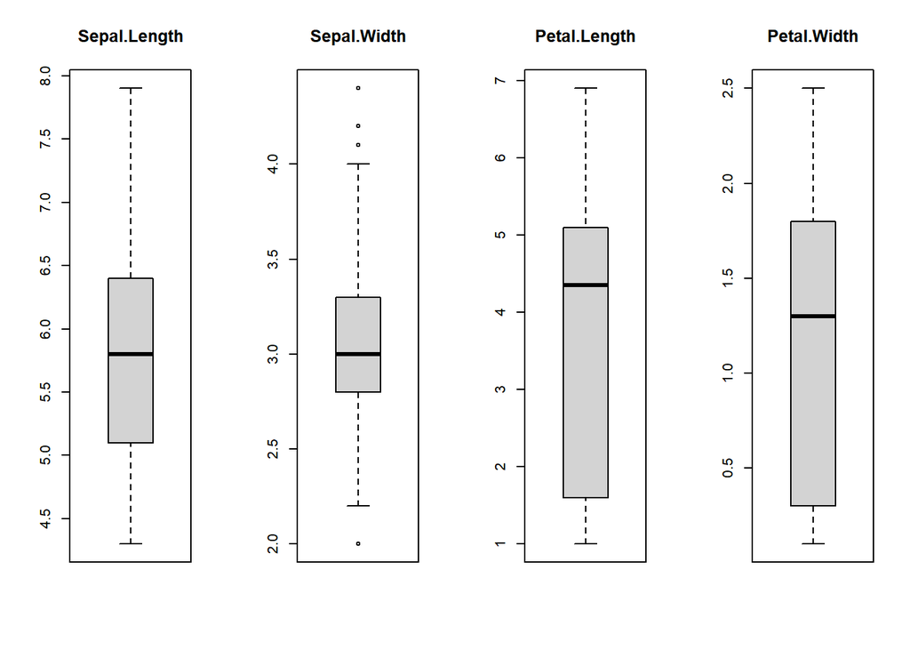

```r
# boxplot for each attribute on one image
par(mfrow=c(1,4))
  for(i in 1:4) {
  boxplot(x[,i], main=names(iris)[i])
  }
```

```r
# barplot for class breakdown
# plot(y)
```

```r
par(mfrow = c(1, 4))
```

## 4.2 Multivariate Plots

Now we can look at the interactions between the variables.

First let’s look at scatterplots of all pairs of attributes and color the points by class. In addition, because the scatterplots show that points for each class are generally separate, we can draw ellipses around them.

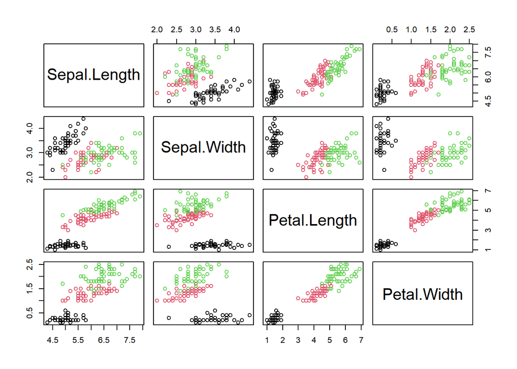

```r
# scatterplot matrix
# featurePlot(x=x, y=y, plot="ellipse")
pairs(iris[, 1:4], col = iris$Species)
```

```r
library(caret)
```

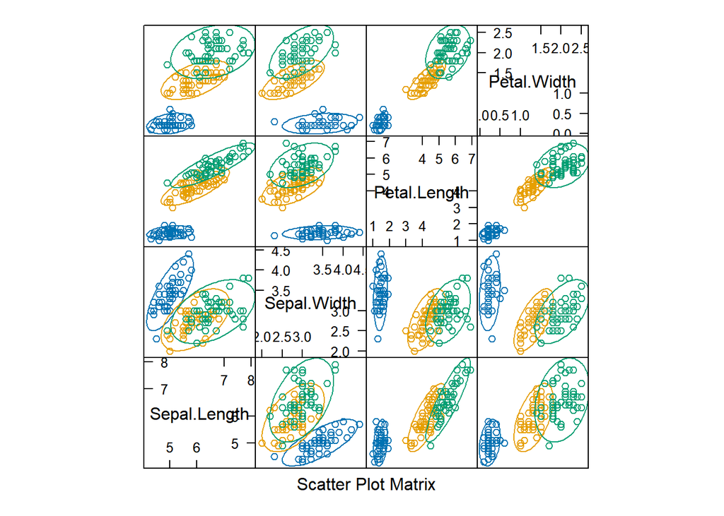

```r
myFeaturePlot = featurePlot(x=x, y=y, plot="ellipse")
# scatterplot matrix
print(myFeaturePlot)
```

```r
# featurePlot(x=x, y=y, plot="ellipse")

# x
# y
```

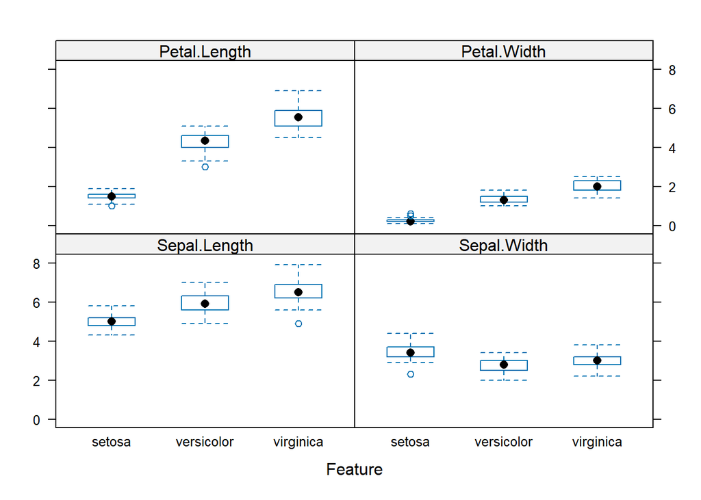

```r
# box and whisker plots for each attribute
featurePlot(x=x, y=y, plot="box")
```

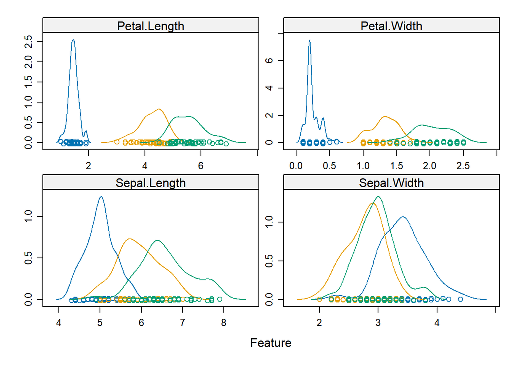

```r
# density plots for each attribute by class value
scales <- list(x=list(relation="free"), y=list(relation="free"))
featurePlot(x=x, y=y, plot="density", scales=scales)
```

### Petal Length vs Petal Width

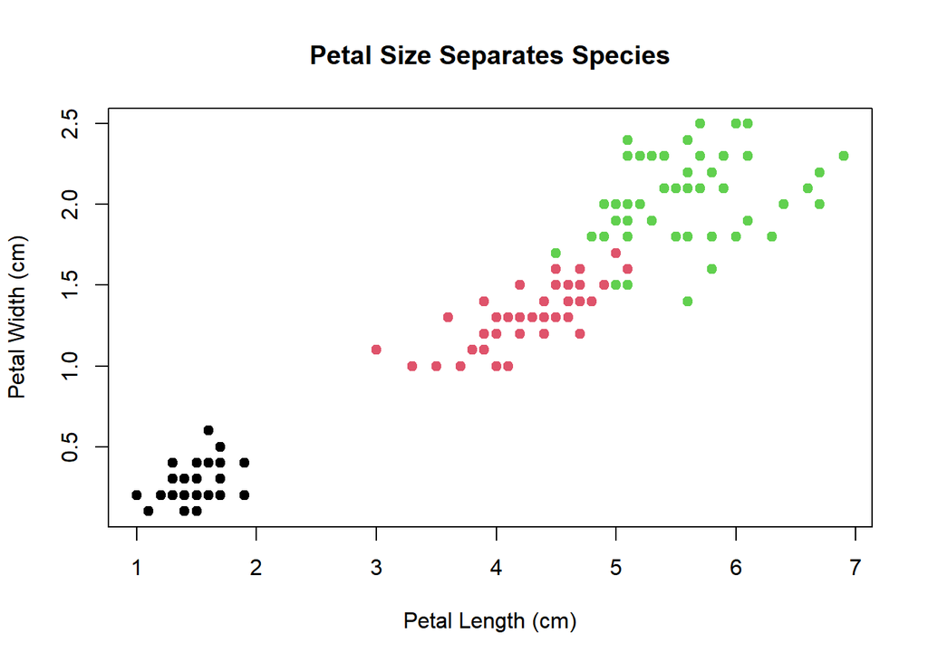

```r
plot(iris$Petal.Length, iris$Petal.Width,
     col = iris$Species,
     pch = 19,
     xlab = "Petal Length (cm)",
     ylab = "Petal Width (cm)",
     main = "Petal Size Separates Species")
```

### Sepal Length vs Sepal Width

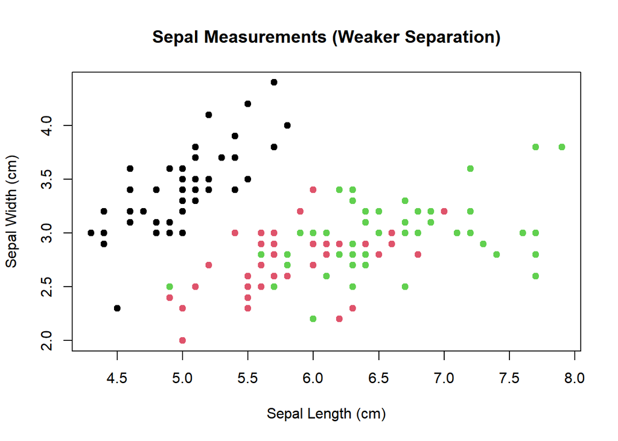

```r
plot(iris$Sepal.Length, iris$Sepal.Width,
     col = iris$Species,
     pch = 19,
     xlab = "Sepal Length (cm)",
     ylab = "Sepal Width (cm)",
     main = "Sepal Measurements (Weaker Separation)")
```

### LDA Projection (LD1)

This shows the linear discriminant pattern directly.

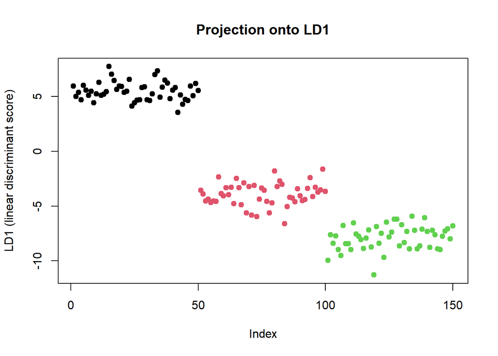

```r
library(MASS)
fit <- lda(Species ~ ., data = iris)
lda_values <- as.matrix(iris[,1:4]) %*% fit$scaling[,1]

plot(lda_values,
     col = iris$Species,
     pch = 19,
     xlab = "Index",
     ylab = "LD1 (linear discriminant score)",
     main = "Projection onto LD1")
```

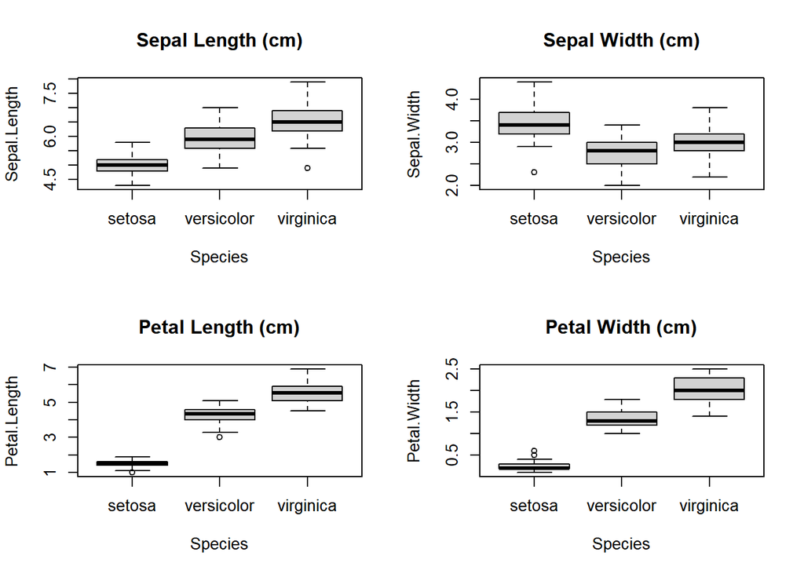

```r
par(mfrow=c(2,2))
boxplot(Sepal.Length ~ Species, data=iris, main="Sepal Length (cm)")
boxplot(Sepal.Width  ~ Species, data=iris, main="Sepal Width (cm)")
boxplot(Petal.Length ~ Species, data=iris, main="Petal Length (cm)")
boxplot(Petal.Width  ~ Species, data=iris, main="Petal Width (cm)")
```

# 5. Evaluate Some Algorithms

Now it is time to create some models of the data and estimate their accuracy on unseen data.

Here is what we are going to cover in this step:

```
Set-up the test harness to use 10-fold cross validation.
Build 5 different models to predict species from flower measurements
Select the best model.
```

## 5.1 Test Harness

```r
# Run algorithms using 10-fold cross validation
control <- trainControl(method="cv", number=10) #- Use 10‑fold cross‑validation
metric <- "Accuracy"
```

## 5.2 Build Models

We don’t know which algorithms would be good on this problem or what configurations to use. We get an idea from the plots that some of the classes are partially linearly separable in some dimensions, so we are expecting generally good results.

Let’s evaluate 5 different algorithms:

[output not shown]

```r
# a) linear algorithms
set.seed(7)
fit.lda <- train(Species~., data=dataset, method="lda", metric=metric, trControl=control)
# b) nonlinear algorithms
# CART
set.seed(7)
fit.cart <- train(Species~., data=dataset, method="rpart", metric=metric, trControl=control)
# kNN
set.seed(7)
fit.knn <- train(Species~., data=dataset, method="knn", metric=metric, trControl=control)
# c) advanced algorithms
# SVM
set.seed(7)
fit.svm <- train(Species~., data=dataset, method="svmRadial", metric=metric, trControl=control)
# Random Forest
set.seed(7)
fit.rf <- train(Species~., data=dataset, method="rf", metric=metric, trControl=control)
```

`A dataset is linearly separable if: There exists some linear combination of features that separates the classes with a straight boundary.`

```r
library(MASS)

fit <- lda(Species ~ ., data = iris)
fit$scaling
```

```
##                     LD1         LD2
## Sepal.Length  0.8293776 -0.02410215
## Sepal.Width   1.5344731 -2.16452123
## Petal.Length -2.2012117  0.93192121
## Petal.Width  -2.8104603 -2.83918785
```

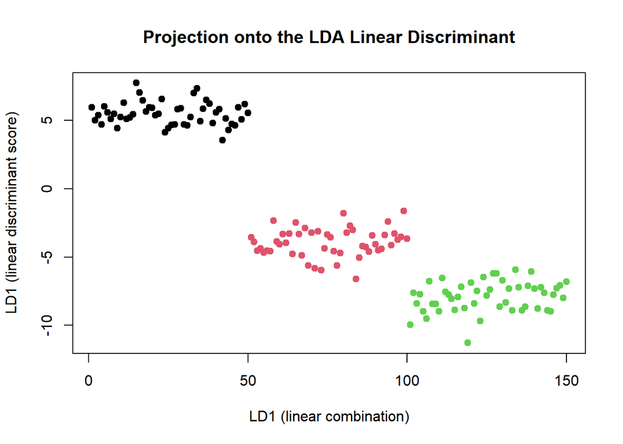

```r
lda_values <- as.matrix(iris[,1:4]) %*% fit$scaling[,1]

plot(lda_values, col = iris$Species,
     pch = 19,
     xlab = "LD1 (linear combination)",
     ylab = "LD1 (linear discriminant score)",
     main = "Projection onto the LDA Linear Discriminant")
```

## 5.3 Select Best Model

```r
# summarize accuracy of models
results <- resamples(list(lda=fit.lda, cart=fit.cart, knn=fit.knn, svm=fit.svm, rf=fit.rf))
summary(results)
```

```
##
## Call:
## summary.resamples(object = results)
##
## Models: lda, cart, knn, svm, rf
## Number of resamples: 10
##
## Accuracy
##           Min.   1st Qu.    Median      Mean   3rd Qu. Max. NA's
## lda  0.9333333 0.9500000 1.0000000 0.9800000 1.0000000    1    0
## cart 0.8666667 0.9333333 0.9333333 0.9400000 0.9833333    1    0
## knn  0.8666667 0.9333333 1.0000000 0.9666667 1.0000000    1    0
## svm  0.8000000 0.9333333 0.9666667 0.9466667 1.0000000    1    0
## rf   0.8666667 0.9333333 0.9666667 0.9600000 1.0000000    1    0
##
## Kappa
##      Min. 1st Qu. Median Mean 3rd Qu. Max. NA's
## lda   0.9   0.925   1.00 0.97   1.000    1    0
## cart  0.8   0.900   0.90 0.91   0.975    1    0
## knn   0.8   0.900   1.00 0.95   1.000    1    0
## svm   0.7   0.900   0.95 0.92   1.000    1    0
## rf    0.8   0.900   0.95 0.94   1.000    1    0
```

We can also create a plot of the model evaluation results and compare the spread and the mean accuracy of each model. There is a population of accuracy measures for each algorithm because each algorithm was evaluated 10 times (10 fold cross validation).

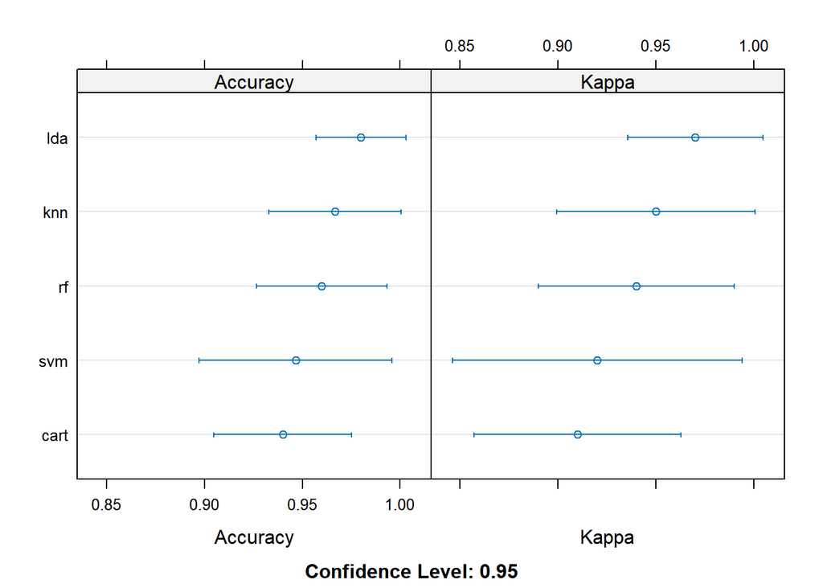

```r
# compare accuracy of models
dotplot(results)
```

```r
# summarize Best Model
print(fit.lda)
```

```
## Linear Discriminant Analysis
##
## 150 samples
##   4 predictor
##   3 classes: 'setosa', 'versicolor', 'virginica'
##
## No pre-processing
## Resampling: Cross-Validated (10 fold)
## Summary of sample sizes: 135, 135, 135, 135, 135, 135, ...
## Resampling results:
##
##   Accuracy  Kappa
##   0.98      0.97
```

```r
summary(fit.lda)
```

```
##             Length Class      Mode
## prior        3     -none-     numeric
## counts       3     -none-     numeric
## means       12     -none-     numeric
## scaling      8     -none-     numeric
## lev          3     -none-     character
## svd          2     -none-     numeric
## N            1     -none-     numeric
## call         3     -none-     call
## xNames       4     -none-     character
## problemType  1     -none-     character
## tuneValue    1     data.frame list
## obsLevels    3     -none-     character
## param        0     -none-     list
```

## 6. Make Predictions

We can run the LDA model directly on the validation set and summarize the results in a confusion matrix.

```r
# estimate skill of LDA on the validation dataset
predictions <- predict(fit.lda, test)
confusionMatrix(predictions, test$Species)
```

```
## Confusion Matrix and Statistics
##
##             Reference
## Prediction   setosa versicolor virginica
##   setosa         10          0         0
##   versicolor      0         14         0
##   virginica       0          1         5
##
## Overall Statistics
##
##                Accuracy : 0.9667
##                  95% CI : (0.8278, 0.9992)
##     No Information Rate : 0.5
##     P-Value [Acc > NIR] : 2.887e-08
##
##                   Kappa : 0.9464
##
##  Mcnemar's Test P-Value : NA
##
## Statistics by Class:
##
##                      Class: setosa Class: versicolor Class: virginica
## Sensitivity                 1.0000            0.9333           1.0000
## Specificity                 1.0000            1.0000           0.9600
## Pos Pred Value              1.0000            1.0000           0.8333
## Neg Pred Value              1.0000            0.9375           1.0000
## Prevalence                  0.3333            0.5000           0.1667
## Detection Rate              0.3333            0.4667           0.1667
## Detection Prevalence        0.3333            0.4667           0.2000
## Balanced Accuracy           1.0000            0.9667           0.9800
```